# stats & figs for gaze as confidence (RSPB revision 03/26)

### SM analysis is extended back to additional lags

Let’s start by looking at Exp 3 and comparing explicit and ocular 3 trials back

Exp. 3 Autocorrelation by Lag & Source

| source | lag | statistic | df | p | effsize | variable | n | mean | ci |
| --- | --- | --- | --- | --- | --- | --- | --- | --- | --- |
| expl | 1 | 8.751 | 31 | < .001 | 1.547 | autocorr_val | 32 | 0.311 | 0.072 |
| expl | 2 | 2.244 | 31 | 0.032 | 0.397 | autocorr_val | 32 | 0.041 | 0.037 |
| expl | 3 | 0.614 | 31 | 0.543 | 0.109 | autocorr_val | 32 | 0.011 | 0.035 |
| gaze | 1 | -0.272 | 31 | 0.788 | -0.048 | autocorr_val | 32 | -0.004 | 0.033 |
| gaze | 2 | 0.637 | 31 | 0.528 | 0.113 | autocorr_val | 32 | 0.012 | 0.037 |
| gaze | 3 | 1.212 | 31 | 0.235 | 0.214 | autocorr_val | 32 | 0.020 | 0.034 |

So we see that expl. conf ratings are signfucantly autocorrelated for lag 2 too!

### Fig. 4D: divergence rate of eye & explicit by P.choice

#### let’s look at exploratory vs. exploitation

summary stats mean diverge by explor/exploit

| explor_exploit | variable | n | mean | ci | lo_ci | hi_ci |
| --- | --- | --- | --- | --- | --- | --- |
| exploit | porp | 56 | 25.560 | 2.352 | 23.208 | 27.912 |
| explor | porp | 54 | 35.471 | 4.740 | 30.731 | 40.211 |

paired ttest of diverge by explor/exploit

| statistic | p.value | parameter | ES |
| --- | --- | --- | --- |
| -4.1347 | 1e-04 | 53 | -0.5627 |

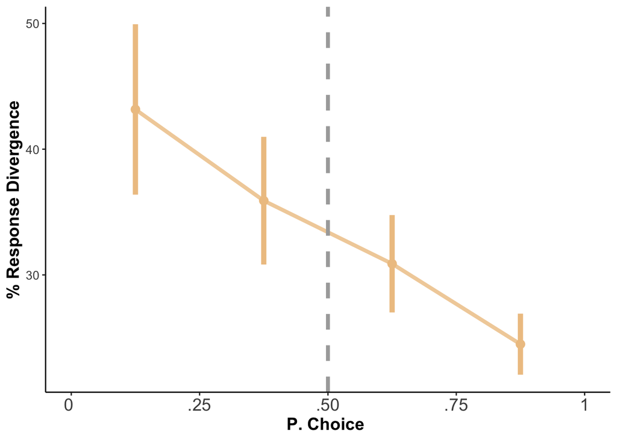

Here we look whether response accuracy tends to be higher when eye/explicit responses converge vs. diverge

summary stats of acc by conv/div & source

| exp_name | eye_resp_match | source | mean_acc | lo_ci | hi_ci |
| --- | --- | --- | --- | --- | --- |
| Exp. 1 | diff | eye | 0.291 | 0.253 | 0.329 |
| Exp. 1 | diff | resp | 0.709 | 0.671 | 0.747 |
| Exp. 1 | same | eye | 0.774 | 0.749 | 0.798 |
| Exp. 1 | same | resp | 0.774 | 0.749 | 0.798 |
| Exp. 2 | diff | eye | 0.285 | 0.241 | 0.329 |
| Exp. 2 | diff | resp | 0.715 | 0.671 | 0.759 |
| Exp. 2 | same | eye | 0.778 | 0.752 | 0.805 |
| Exp. 2 | same | resp | 0.778 | 0.752 | 0.805 |
| Exp.1&2 | diff | eye | 0.287 | 0.259 | 0.316 |
| Exp.1&2 | diff | resp | 0.713 | 0.684 | 0.741 |
| Exp.1&2 | same | eye | 0.776 | 0.759 | 0.794 |
| Exp.1&2 | same | resp | 0.776 | 0.759 | 0.794 |

ttest results of resp acc by conv/diver

| statistic | p.value | parameter | ES |
| --- | --- | --- | --- |
| -4.7468 | 0 | 55 | -0.6343 |

### SM figure S10:

diverge % by explore/exploit trials P. Choice

paired ttest of diverge by explor/exploit by pchoice different source

| statistic | p.value | parameter | ES | p. Choice source |
| --- | --- | --- | --- | --- |
| -4.135 | 0 | 53 | -0.563 | Explicit |
| -16.685 | 0 | 55 | -2.230 | Gaze |

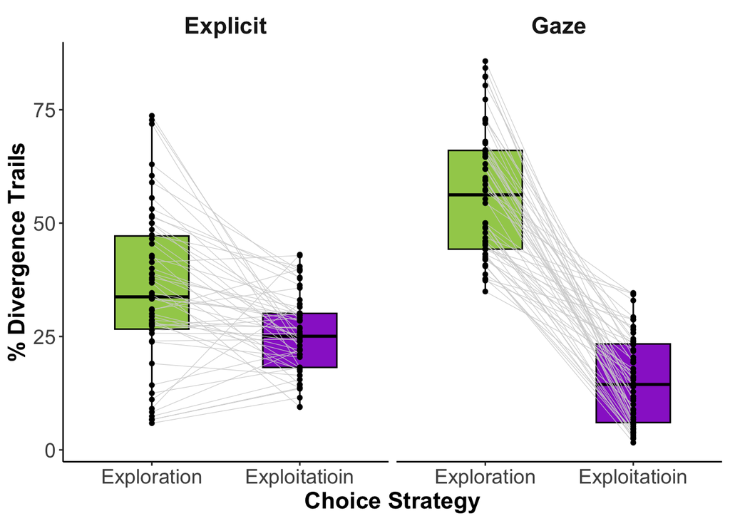

### Figue S11 Accurcy on Diverging and converging trials

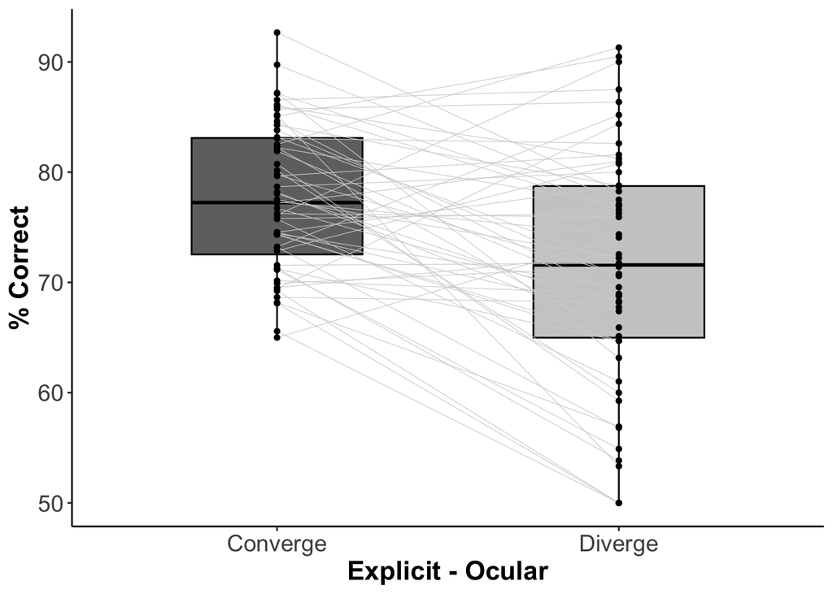

## SM Fig S12-16

These are additional analyses of Pre-Registartion of Exp. 3

### Hypothesis H3a: Confidence decreases following errors:

From the pre-reg “we anticipate that confidence will decrease after trials in which the participant’s response was incorrect as opposed to correct. This will be tested across participants using a paired t-test to compare confidence ratings following previous trials in which the response was correct/incorrect”

smry stats conf by prev. trial acc

| mean_diff | lo_ci | hi_ci | t | df | p.val | ES |
| --- | --- | --- | --- | --- | --- | --- |
| 0.79 | 0.61 | 0.98 | 8.73 | 31 | 0 | 1.54 |

#### Fig. S12A

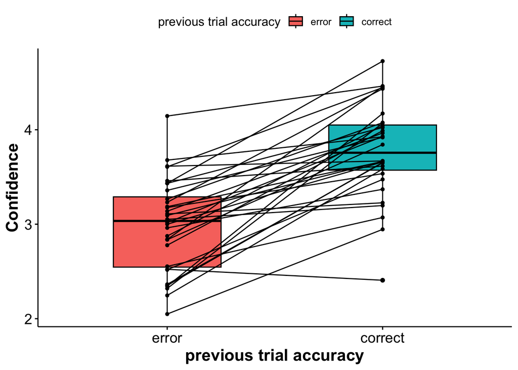

#### Pre reg EXP 3- H3A: confidence learning curve

“Further supporting the idea that confidence tracks learning we expect confidence to exhibit a learning curve. Within a block (a series of trials that follow the same underlying rule), we expect normalized confidence ratings to exhibit a learning curve that is characterized by a monotonic increase during the early trials until an asymptote is reached”

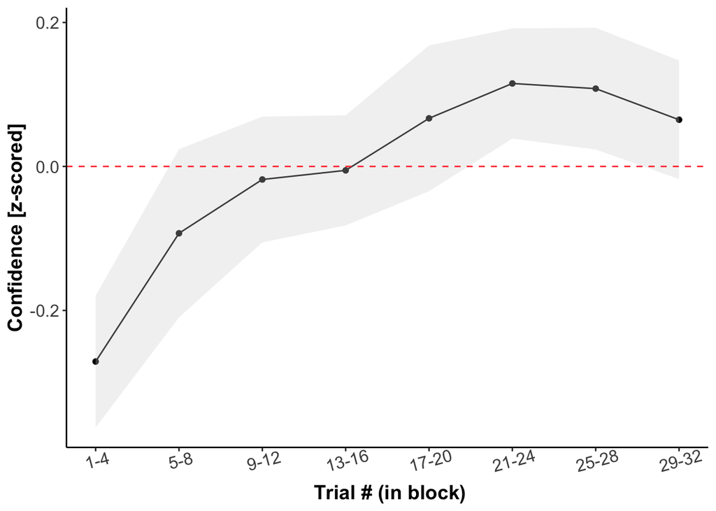

### Pre-reg H3b: Confidence is increased for correct trials as opposed to incorrect trials:

In line with extensive work demonstrating human’s metacognitive abilities (Fleming & Daw, 2017; Maniscalco & Lau, 2012), we expect normalized confidence ratings to be increased for trials in which the prediction is in line with the underlying rule (i.e. rule accuracy). This will be tested across participants using a paired t-test to compare confidence on trials with correct/incorrect rule accuracy (see figure “Confidence by Rule Accuracy”).

Figure “Confidence by Rule Accuracy”. Comparing trials by their rule accuracy, we expect that across participants the mean confidence rating will be significantly higher for correct as opposed to incorrect trials.

smry stats conf by trial acc

| is_acc | accuracy_type | variable | n | mean | ci | lo_ci | hi_ci |
| --- | --- | --- | --- | --- | --- | --- | --- |
| 0 | Actual | m_conf | 32 | 0.36 | 0.15 | 0.20 | 0.51 |
| 1 | Actual | m_conf | 32 | 0.53 | 0.15 | 0.38 | 0.68 |
| 0 | Rule | m_conf | 32 | 0.02 | 0.17 | -0.15 | 0.19 |
| 1 | Rule | m_conf | 32 | 0.61 | 0.15 | 0.45 | 0.76 |

stats tests conf by trial acc

| accuracy_type | statistic | df | p | effsize |
| --- | --- | --- | --- | --- |
| Actual | -4.828 | 31 | 0 | -0.853 |
| Rule | -10.437 | 31 | 0 | -1.845 |

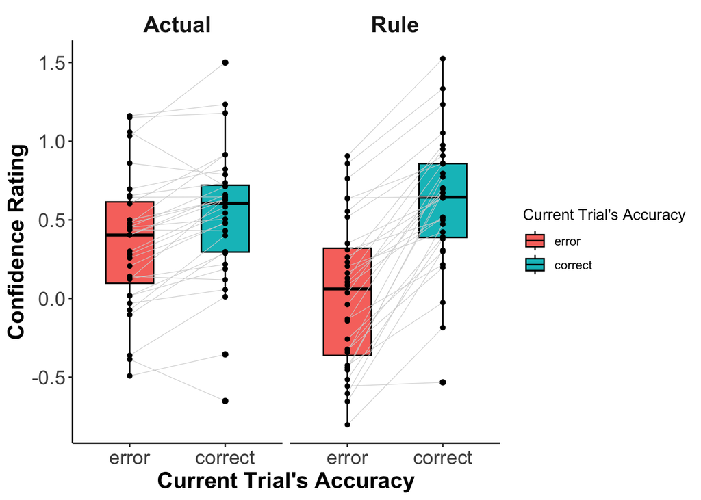

### Pre reg EXP 3: H3c: Explicit confidence & RW trajectory

“H3C: Confidence tracks the latent variable of previous trial’s Prediction Error (derived from R-W Model): In accordance with Hypothesis 3a, which states that confidence ratings will be updated by the previous trial’s accuracy, and in line with previous research that has found that confidence ratings track internal learning processes (Meyniel et al., 2015), we expect confidence ratings to be significantly correlated with the previous trial’s absolute prediction error. To test this for each participant we will correlate the trial’s Confidence Rating and the previous trial’s Prediction Error. We will then run a one-sample t-test on the participants’ Pearson correlations’ distribution. We hypothesize that the distribution will be significantly greater than zero and moderate . In addition to the previous trial’s prediction error as an exploratory analysis we will examine confidence rating’s correlation to the probability associated with the choice made (P. Choice) and the strength of the value associated with the choice (v; this is quantified as the distance of v from 0.5), that are also derived from the R-W model.”

correlation Confidence Ratings and RWS learning metrics

| vars_compared | mean_corr | hi_CI | lo_CI | group_t_statistic | group_pval | ES | n_sig | total_sub |
| --- | --- | --- | --- | --- | --- | --- | --- | --- |
| conf_PC | 0.384 | 0.438 | 0.330 | 14.468 | 0 | 2.558 | 30 | 32 |
| conf_dist_v | 0.285 | 0.362 | 0.209 | 7.604 | 0 | 1.366 | 23 | 31 |
| conf_prev_delta | -0.266 | -0.195 | -0.337 | -7.612 | 0 | -1.346 | 22 | 32 |

#### Fig. S13

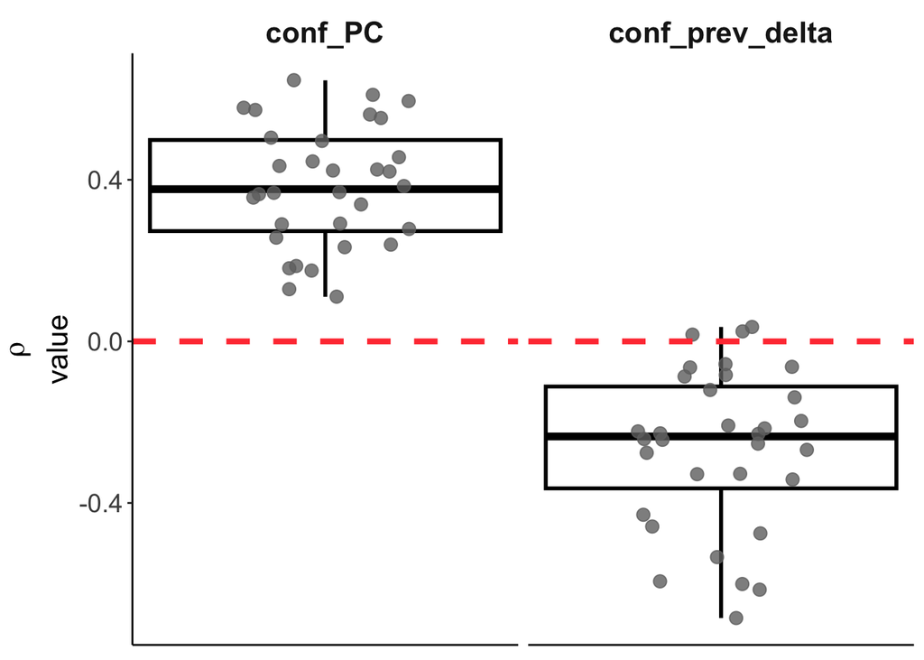

### Exp 3: Pre_reg Hypothesis 4

####4A Gaze is associated with explicot prediction Hypothesis 4a: Gaze direction is strongly associated with the direction of the explicit prediction: To examine how explicit responses and implicit ocular expectations are related, we will take the normalized gaze direction of the first 300 msec in the environment (see Figure “Association Between Explicit Predictions and Gaze” left panel) and average it per trial and per Prediction (right/ left). We then compare the effect of explicit Prediction on Normalized Gaze across participants using a paired t-test (see Figure “Association Between Explicit Predictions and Gaze” right panel). We expect a significant effect of Prediction on Normalized Gaze.

#### Fig. S14A

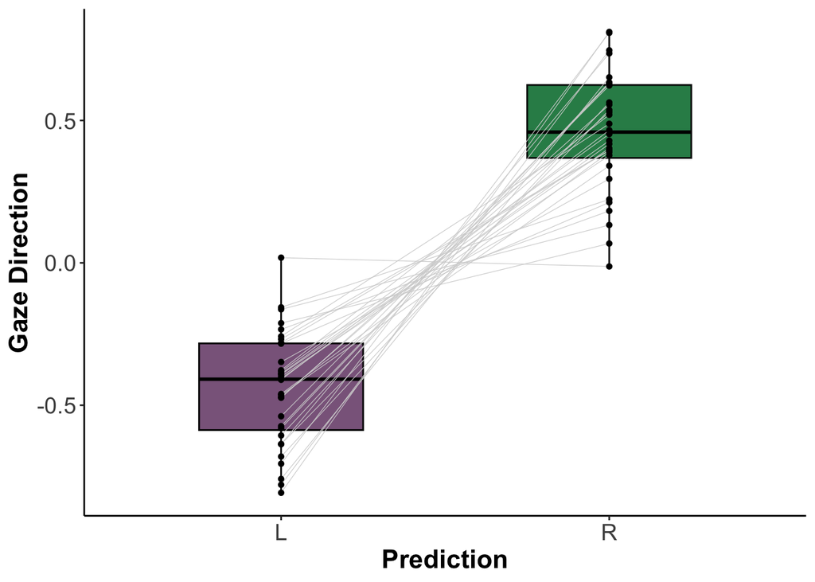

Diff gaze direction by prediction Exp 3 (pre-reg)

| mean_diff | lo_ci | hi_ci | t | df | p.val | ES |
| --- | --- | --- | --- | --- | --- | --- |
| 0.9 | 0.75 | 1.04 | 12.79 | 31 | 0 | 2.26 |

#### Fig. S14B

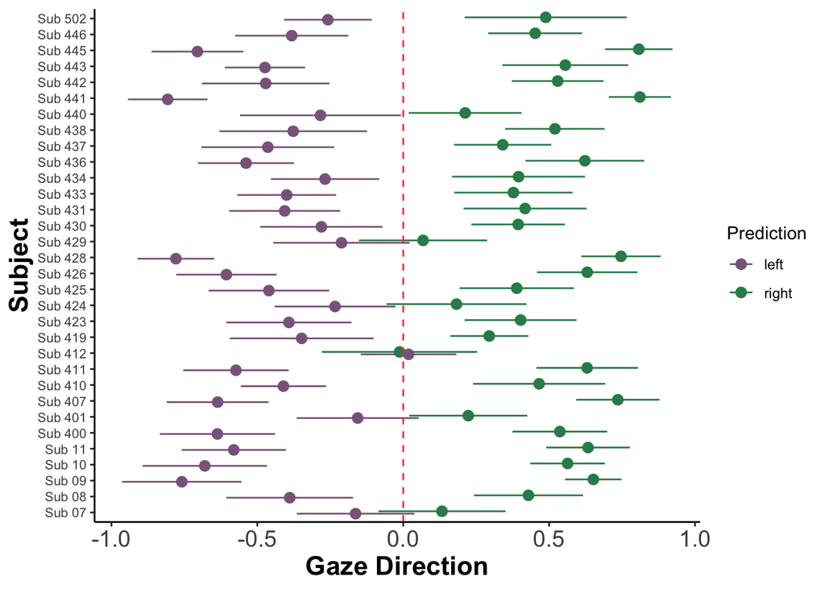

Gaze by Prediction, single ss signfiacne

| exp_name | n_sig | total_n |
| --- | --- | --- |
| Exp. 3 | 30 | 32 |

### H4: A gaze Prediction is correlated to P. Choice

EXP 3correlation EM and learning metric RW (PreReg sub)

| exp_name | vars_compared | mean_corr | lo_corr | hi_corr | group_t_statistic | group_pval | ES | n_sig | total_sub |
| --- | --- | --- | --- | --- | --- | --- | --- | --- | --- |
| Exp. 3 | PC_pred_gz | 0.070 | 0.104 | 0.037 | 4.258 | 0.000 | 0.753 | NA | NA |
| Exp. 3 | da_pred_gz | -0.051 | -0.023 | -0.078 | -3.791 | 0.001 | -0.670 | NA | NA |
| Exp. 3 | distv5_pred_gz | NaN | NaN | NaN | 6.262 | 0.000 | 1.125 | NA | NA |

#### Fig. S15

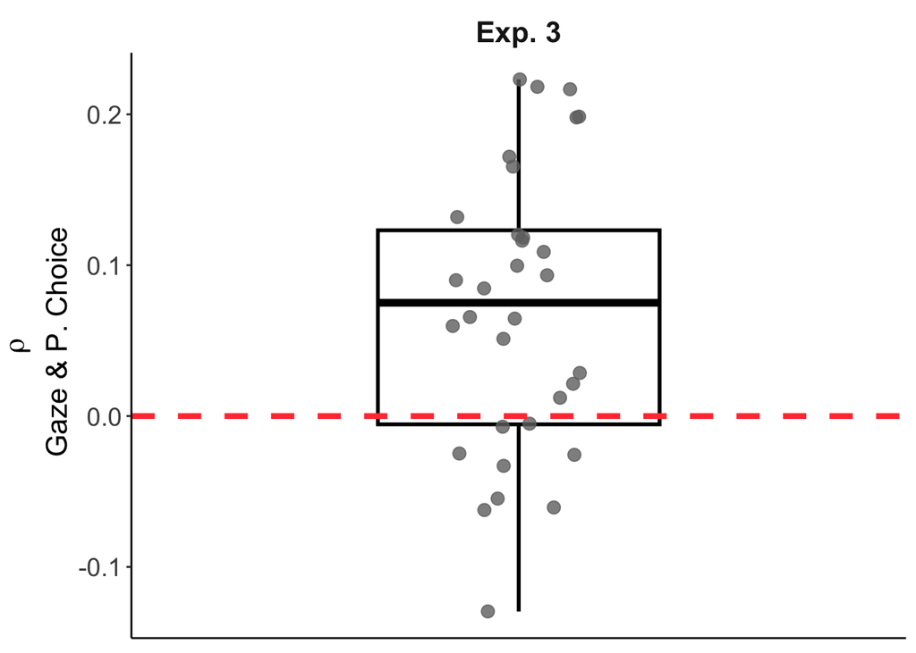

### H4:B Gaze fulfills benchmarks of confidence

“Hypothesis 4b:”Gaze exhibits the three statistical hallmarks of confidence”: In brief (see https://osf.io/t49pj for full explanation), we will examine whether gaze reflects confidence and fulfills the three statistical hallmarks of confidence (Sanders et al., 2016)”

Exp 3 Conf benchmark 1 distribution of spearman correlation

| exp_name | mean_corr | lo_corr | hi_corr | group_t_statistic | group_pval | ES |
| --- | --- | --- | --- | --- | --- | --- |
| Exp. 3 | 0.1767 | 0.3595 | -0.0062 | 1.9707 | 0.0577 | 0.3484 |

So this is almost sig. but not a very good way to test it…

Conf benchmark 1 with glmer

| effect | group | term | estimate | std.error | statistic | p.value | exp_name |
| --- | --- | --- | --- | --- | --- | --- | --- |
| fixed | NA | (Intercept) | 1.04042 | 0.06487 | 16.03931 | 0 | Exp. 1 |
| fixed | NA | m_pred_gz | 0.26507 | 0.04654 | 5.69518 | 0 | Exp. 1 |
| ran_pars | sub_name | sd__(Intercept) | 0.24597 | NA | NA | NA | Exp. 1 |

#### Fig S16A

Vizulaize benchmark 1

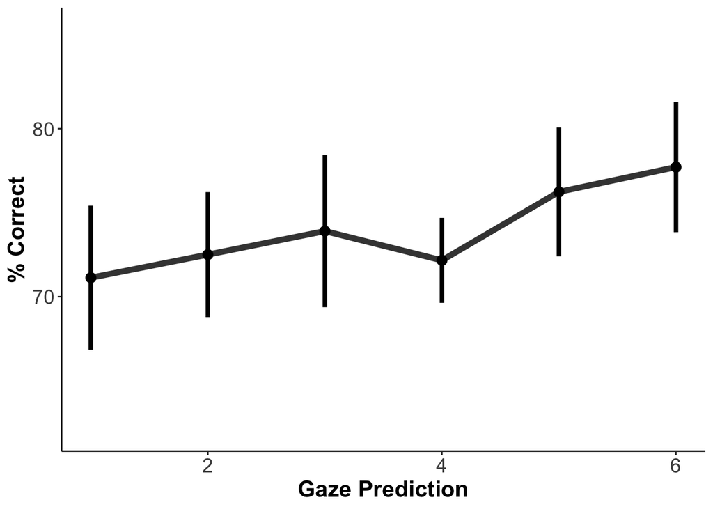

### Fig S16B

Benchmark 2: folded X

#### Running with RWS

EXP 3. RWS lme results Benchmark 2

| term | npar | AIC | BIC | logLik | deviance | statistic | df | p.value | exp |
| --- | --- | --- | --- | --- | --- | --- | --- | --- | --- |
| bench2_full_exp3.res_rws | 6 | 11933.21 | 11972.15 | -5960.607 | 11921.21 | 1.906 | 1 | 0.1674 | Exp. 3 |

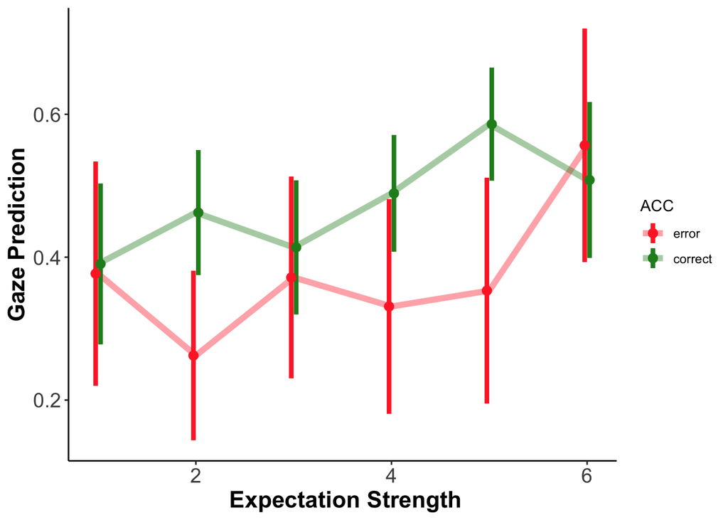

#### Fig S16C

Confidence Benchmark 3: EXP3

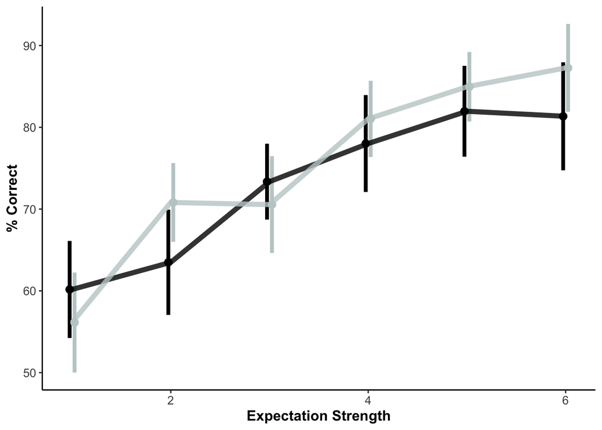

Exp 3Benchmark 3 RWS (glmer)

| effect | group | term | estimate | std.error | statistic | p.value | exp_name |
| --- | --- | --- | --- | --- | --- | --- | --- |
| fixed | NA | (Intercept) | 0.3266672 | 0.2311633 | 1.413144 | 0.1576133 | Exp. 1 |
| fixed | NA | pred_gz_bin | -0.1611013 | 0.1439355 | -1.119261 | 0.2630290 | Exp. 1 |
| fixed | NA | dist_v_bin | 0.1741175 | 0.0641453 | 2.714422 | 0.0066392 | Exp. 1 |
| fixed | NA | pred_gz_bin:dist_v_bin | 0.0830579 | 0.0410870 | 2.021512 | 0.0432268 | Exp. 1 |

## Fig. S17

Parameter recovery

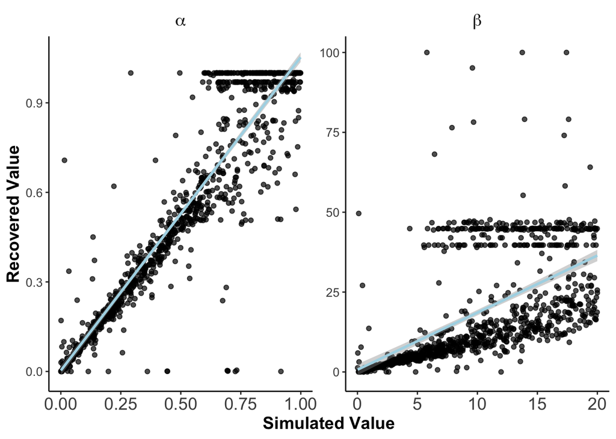

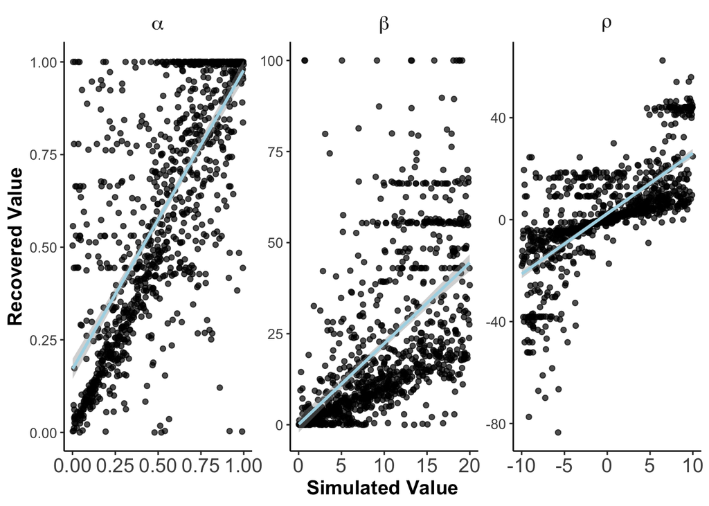

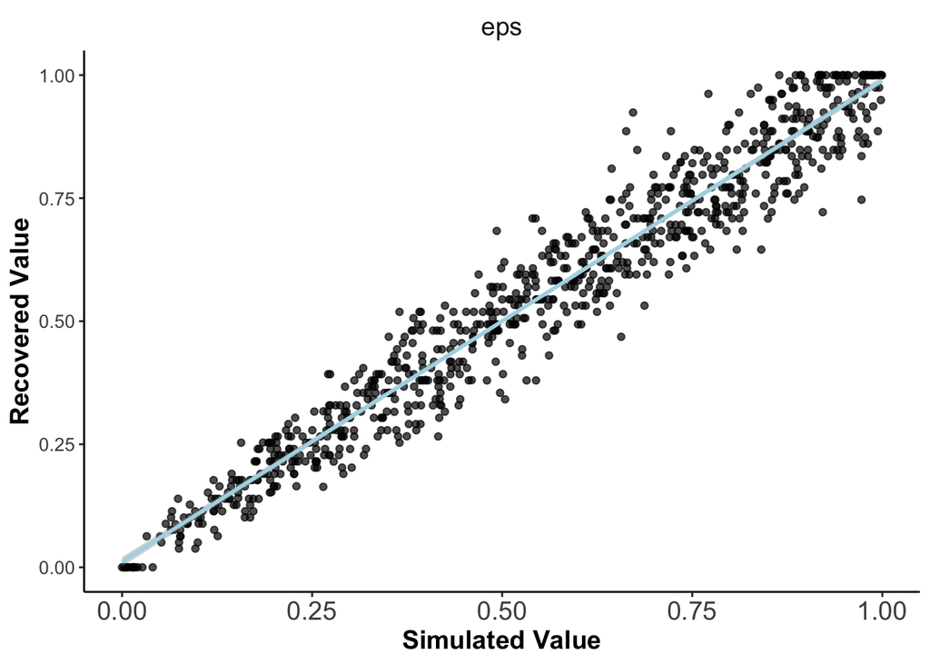

paramater recovery correlation values

| param_name | var1 | var2 | cor | statistic | p | conf.low | conf.high | method | model |
| --- | --- | --- | --- | --- | --- | --- | --- | --- | --- |
| alpha | sim | rec | 0.92 | 74.93 | 0 | 0.91 | 0.93 | Pearson | RW |
| beta | sim | rec | 0.59 | 22.84 | 0 | 0.54 | 0.63 | Pearson | RW |
| alpha | sim | rec | 0.73 | 33.85 | 0 | 0.70 | 0.76 | Pearson | RWS |
| beta | sim | rec | 0.57 | 21.88 | 0 | 0.53 | 0.61 | Pearson | RWS |
| rho | sim | rec | 0.71 | 31.61 | 0 | 0.67 | 0.74 | Pearson | RWS |
| eps | sim | rec | 0.97 | 122.86 | 0 | 0.97 | 0.98 | Pearson | WSLS |